# Statistical Inference Course Project 2

Xiaoyi Leo Liu

### Overview

In this project, we are going to analyze the ToothGrowth data in the R datasets package.

1. Load the ToothGrowth data in the R datasets package and perform some basic exploratory data analyses.
2. Provide a basic summary of the data.
3. Use confidence intervals and/or hypothesis tests to compare tooth growth by supp and dose (only use the techniques from class, even if there’s other approaches worth considering).
4. State our conclusions and the assumptions needed for our conclusions.

### Load Data and Basic Summary

```r
library(datasets)
data(ToothGrowth)
str(ToothGrowth)
```

```
## 'data.frame':    60 obs. of  3 variables:
##  $ len : num  4.2 11.5 7.3 5.8 6.4 10 11.2 11.2 5.2 7 ...
##  $ supp: Factor w/ 2 levels "OJ","VC": 2 2 2 2 2 2 2 2 2 2 ...
##  $ dose: num  0.5 0.5 0.5 0.5 0.5 0.5 0.5 0.5 0.5 0.5 ...
```

```r
head(ToothGrowth)
```

```
##    len supp dose
## 1  4.2   VC  0.5
## 2 11.5   VC  0.5
## 3  7.3   VC  0.5
## 4  5.8   VC  0.5
## 5  6.4   VC  0.5
## 6 10.0   VC  0.5
```

```r
ToothGrowth$dose = as.factor(ToothGrowth$dose)
ToothGrowth$supp = as.factor(ToothGrowth$supp)
summary(ToothGrowth)
```

```
##       len        supp     dose
##  Min.   : 4.20   OJ:30   0.5:20
##  1st Qu.:13.07   VC:30   1  :20
##  Median :19.25           2  :20
##  Mean   :18.81
##  3rd Qu.:25.27
##  Max.   :33.90
```

We also plot the length of teeth versus dose with different supplements.

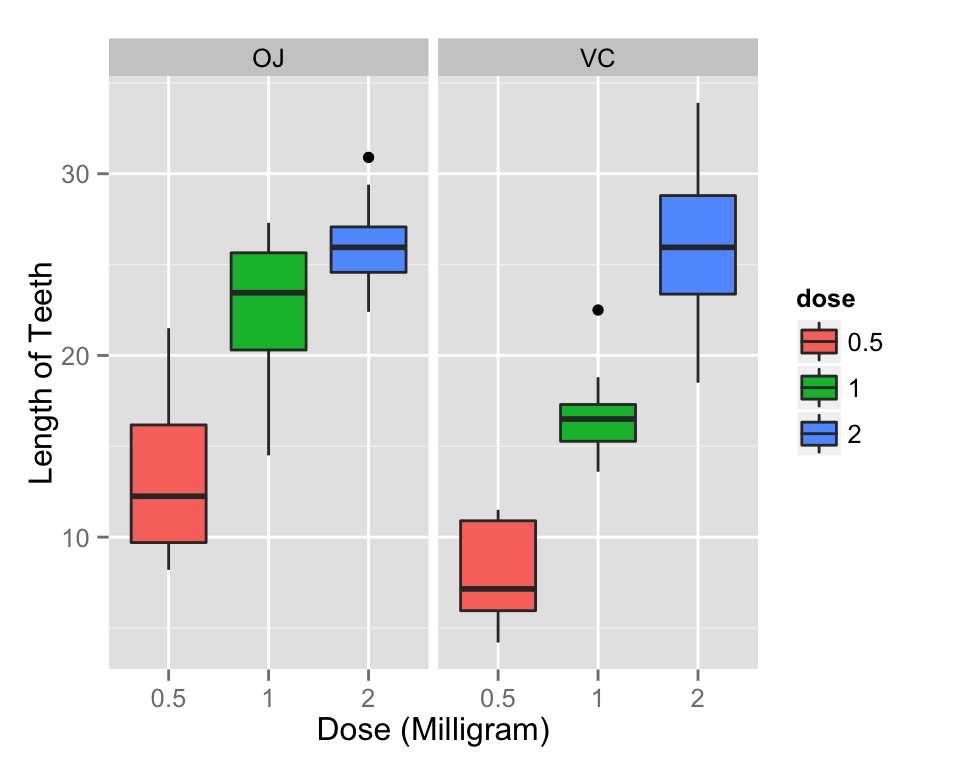

```r
library(ggplot2)
plt = ggplot(ToothGrowth, aes(x = dose, y = len, fill = dose)) + geom_boxplot(notch = FALSE) + facet_grid(.~ supp) + scale_x_discrete("Dose (Milligram)") + scale_y_continuous("Length of Teeth")
plt
```

### Comparing Tooth Growth

In this section, we use confidence intervals and hypothesis tests to compare tooth growth by **supp** and **dose**. The null hypothesis we assume is that the means of the two tested groups are equal, while the alternative one is the observed difference in tooth lengths is significant. We will reject the null hypothesis if the corresponding p-value is less than 0.05.

```r
supp_dose05 = t.test(len ~ supp, data = subset(ToothGrowth, dose = 0.5), var.equal = FALSE)
supp_dose1 = t.test(len ~ supp, data = subset(ToothGrowth, dose = 1), var.equal = FALSE)
supp_dose2 = t.test(len ~ supp, data = subset(ToothGrowth, dose = 2), var.equal = FALSE)

supp_dose = data.frame(rownames = c("dose = 0.5", "dose = 1.0", "dose = 2.0"), "p-value" = c(supp_dose05$p.value, supp_dose1$p.value, supp_dose2$p.value), "Conf_Low" = c(supp_dose05$conf[1], supp_dose1$conf[1], supp_dose2$conf[1]), "Conf_High" = c(supp_dose05$conf[2], supp_dose1$conf[2], supp_dose2$conf[2]))

supp_dose
```

```
##     rownames    p.value   Conf_Low Conf_High
## 1 dose = 0.5 0.06063451 -0.1710156  7.571016
## 2 dose = 1.0 0.06063451 -0.1710156  7.571016
## 3 dose = 2.0 0.06063451 -0.1710156  7.571016
```

Second, we will test the effect of dosages on tooth length.

```r
suppVC_dose05_1 = t.test(len ~ dose, data = subset(ToothGrowth, supp == 'VC' & (dose == 0.5 |dose == 1.0)), var.equal = FALSE)
suppOJ_dose05_1 = t.test(len ~ dose, data = subset(ToothGrowth, supp == 'OJ' & (dose == 0.5 |dose == 1.0)), var.equal = FALSE)

suppVC_dose05_2 = t.test(len ~ dose, data = subset(ToothGrowth, supp == 'VC' & (dose == 0.5 |dose == 2.0)), var.equal = FALSE)
suppOJ_dose05_2 = t.test(len ~ dose, data = subset(ToothGrowth, supp == 'OJ' & (dose == 0.5 |dose == 2.0)), var.equal = FALSE)

suppVC_dose1_2 = t.test(len ~ dose, data = subset(ToothGrowth, supp == 'VC' & (dose == 1.0 |dose == 2.0)), var.equal = FALSE)
suppOJ_dose1_2 = t.test(len ~ dose, data = subset(ToothGrowth, supp == 'OJ' & (dose == 1.0 |dose == 2.0)), var.equal = FALSE)


dose_supp = data.frame(rownames = c("supp = 'VC', dose = 0.5 or 1", "supp = 'OJ', dose = 0.5 or 1", "supp = 'VC', dose = 0.5 or 2", "supp = 'OJ', dose = 0.5 or 2", "supp = 'VC', dose = 1 or 2", "supp = 'OJ', dose = 1 or 2"), "p-value" = c(suppVC_dose05_1$p.value, suppOJ_dose05_1$p.value, suppVC_dose05_2$p.value, suppOJ_dose05_2$p.value, suppVC_dose1_2$p.value, suppOJ_dose1_2$p.value), "Conf_Low" = c(suppVC_dose05_1$conf[1], suppOJ_dose05_1$conf[1], suppVC_dose05_2$conf[1], suppOJ_dose05_2$conf[1], suppVC_dose1_2$conf[1], suppOJ_dose1_2$conf[1]), "Conf_High" = c(suppVC_dose05_1$conf[2], suppOJ_dose05_1$conf[2], suppVC_dose05_2$conf[2], suppOJ_dose05_2$conf[2], suppVC_dose1_2$conf[2], suppOJ_dose1_2$conf[2]))
dose_supp
```

```
##                       rownames      p.value   Conf_Low   Conf_High
## 1 supp = 'VC', dose = 0.5 or 1 6.811018e-07 -11.265712  -6.3142880
## 2 supp = 'OJ', dose = 0.5 or 1 8.784919e-05 -13.415634  -5.5243656
## 3 supp = 'VC', dose = 0.5 or 2 4.681577e-08 -21.901512 -14.4184880
## 4 supp = 'OJ', dose = 0.5 or 2 1.323784e-06 -16.335241  -9.3247594
## 5   supp = 'VC', dose = 1 or 2 9.155603e-05 -13.054267  -5.6857333
## 6   supp = 'OJ', dose = 1 or 2 3.919514e-02  -6.531443  -0.1885575
```